# CI_Project2_Titanic

GV_AS

25 December 2015

Predicting Survival on the Titanic

The objective of the competition is to predict whether a passenger would survive or not.One of the reasons that the shipwreck led to such loss of life was that there were not enough lifeboats for the passengers and crew. Although there was some element of luck involved in surviving the sinking, some groups of people were more likely to survive than others, such as women, children, and the upper-class.

Setting your working directory:

```r
setwd("C:/Users/shankar/Desktop")
load('.RData')
```

Loading Data

```r
train<-read.csv('train.csv')
test<- read.csv('test.csv')
```

The Training dataset consits of 891 rows and 12 columns.

```
##  [1] "PassengerId" "Survived"    "Pclass"      "Name"        "Sex"
##  [6] "Age"         "SibSp"       "Parch"       "Ticket"      "Fare"
## [11] "Cabin"       "Embarked"
```

Distribution of Sexes among the population

```
##
## female   male
##    314    577
```

Rate of survival for Males and Females

```
##
##            0   1
##   female  81 233
##   male   468 109
```

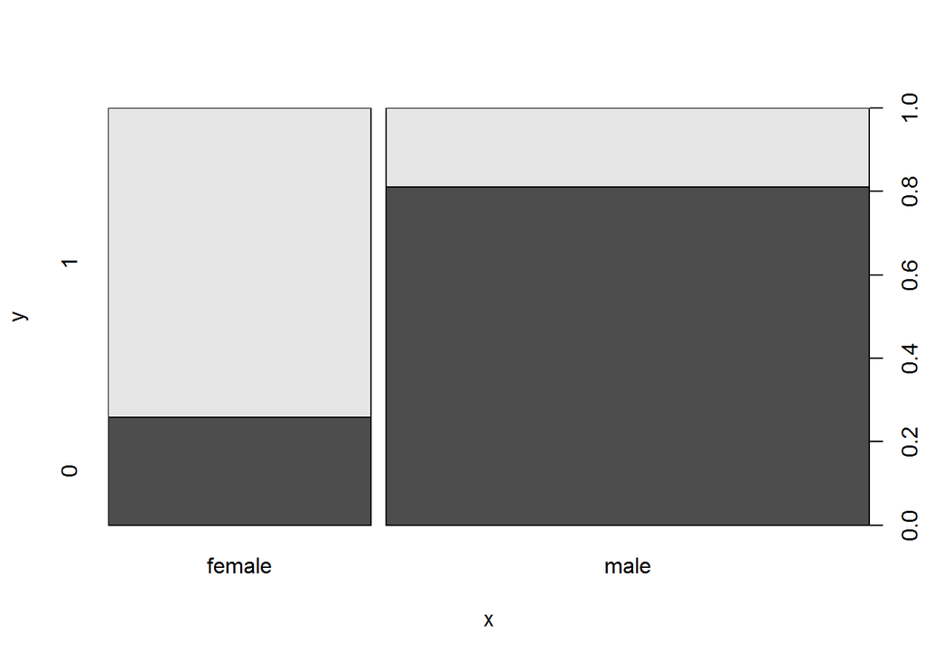

Females have a better survival rate. 75% of the women have survived, whereas only 18% of men survived.

Distribution of people across classes

```
##
##   1   2   3
## 216 184 491
```

Does the passenger class have an impact on survival?

```
##
##       0   1
##   1  80 136
##   2  97  87
##   3 372 119
```

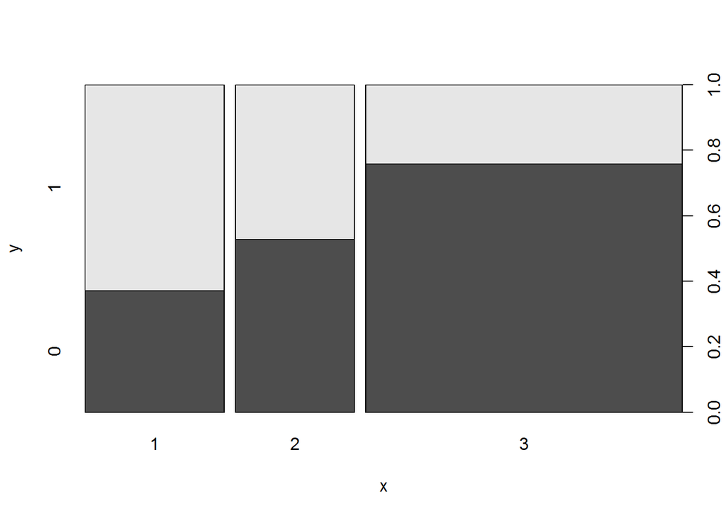

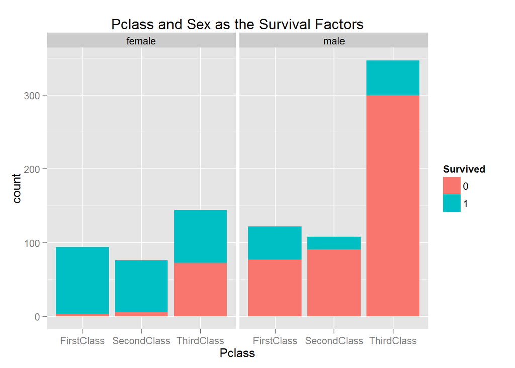

Females in the upper classes have a higher rate of survival

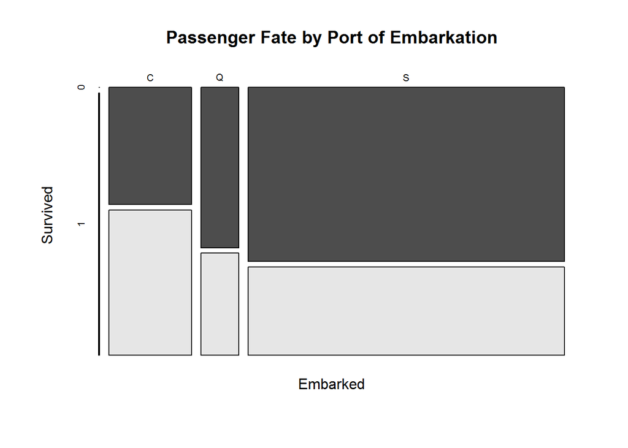

While passenger survival didn’t vary as much across the three ports of embarkation as it did between genders and traveling classes, perhaps the Embarked feature will prove useful at some point.

Let’s now move on to AGE.

```
##    Min. 1st Qu.  Median    Mean 3rd Qu.    Max.    NA's
##    0.42   20.12   28.00   29.70   38.00   80.00     177
```

There are 177 NA’s in AGE.

Let’s do a summary of Fare.

```
##    Min. 1st Qu.  Median    Mean 3rd Qu.    Max.
##    0.00    7.91   14.45   32.20   31.00  512.30
```

Zero Fare?

```r
subset(train, Fare < 5, select = c(Age, Fare))
```

```
##     Age   Fare
## 180  36 0.0000
## 264  40 0.0000
## 272  25 0.0000
## 278  NA 0.0000
## 303  19 0.0000
## 379  20 4.0125
## 414  NA 0.0000
## 467  NA 0.0000
## 482  NA 0.0000
## 598  49 0.0000
## 634  NA 0.0000
## 675  NA 0.0000
## 733  NA 0.0000
## 807  39 0.0000
## 816  NA 0.0000
## 823  38 0.0000
```

some error here, let’s substitute the zero fares with the median values of the fares corresponding to each passenger class.

```r
aggregate(Fare~Pclass,train,median)
```

```
##   Pclass    Fare
## 1      1 60.2875
## 2      2 14.2500
## 3      3  8.0500
```

Lets combine Train and Test Data , as fix for Age and Fare has to done in both datasets.

```r
#Combining the data
test$Survived<-NA
combi<-rbind(train,test)
```

```r
#Extracting the information from Names to predict missing ages
combi$Name <- as.character(combi$Name)
strsplit(combi$Name[1], split='[,.]')
```

```
## [[1]]
## [1] "Braund"       " Mr"          " Owen Harris"
```

```r
strsplit(combi$Name[1], split='[,.]')[[1]]
```

```
## [1] "Braund"       " Mr"          " Owen Harris"
```

```r
strsplit(combi$Name[1], split='[,.]')[[1]][2]
```

```
## [1] " Mr"
```

```r
combi$Title <- sapply(combi$Name, FUN=function(x) {strsplit(x, split='[,.]')[[1]][2]})
combi$Title <- sub(' ', '', combi$Title)
combi$Title[combi$Title %in% c('Capt', 'Don', 'Major', 'Sir')] <- 'Mr'
combi$Title[combi$Title %in% c('Col','Dr','Jonkheer','Rev')] <- 'Mr'
combi$Title[combi$Title %in% c('the Countess','Mme','Dona','Lady')] <- 'Mrs'
combi$Title[combi$Title %in% c('Mlle')] <- 'Miss'
combi$Fare[is.na(combi$Fare)] <- mean(combi$Fare, na.rm=TRUE)
combi$FamId<- combi$SibSp+ combi$Parch

#Predicting NAs of Age

for (i in 1:1309) {
  if(is.na(combi$Age[i])){
    if(combi$Title[i]=="Master"){combi$Age[i]<-sample(1:17,1)}
    else if(combi$Title[i]=="Mr"){combi$Age[i]<-sample(18:50,1)}
    else if(combi$Title[i]=="Miss"){combi$Age[i]<-sample(18:29,1)}
    else if(combi$Title[i]=="Mrs"){combi$Age[i]<-sample(30:60,1)}
    else{combi$Age[i]<-sample(18:60,1)}
  }
}

#Predicting the errors in Fares
for(i in 1:1309){
  if(combi$Fare[i]<7 && combi$Pclass[i]==1){combi$Fare[i]<-60}
  else if(combi$Fare[i]<7 && combi$Pclass[i]==2){combi$Fare[i]<-14}
  else if(combi$Fare[i]<7 && combi$Pclass[i]==3){combi$Fare[i]<-8}
  else{combi$Fare[i]<-combi$Fare[i]}
}

#Splitting back the train and test data
train <- combi[1:891,]
test <- combi[892:1309,]
```

summary of Age.

```
##    Min. 1st Qu.  Median    Mean 3rd Qu.    Max.
##    0.42   21.00   29.00   30.43   39.00   80.00
```

summary of Fare.

```
##    Min. 1st Qu.  Median    Mean 3rd Qu.    Max.
##   7.046   8.000  14.500  32.750  31.280 512.300
```

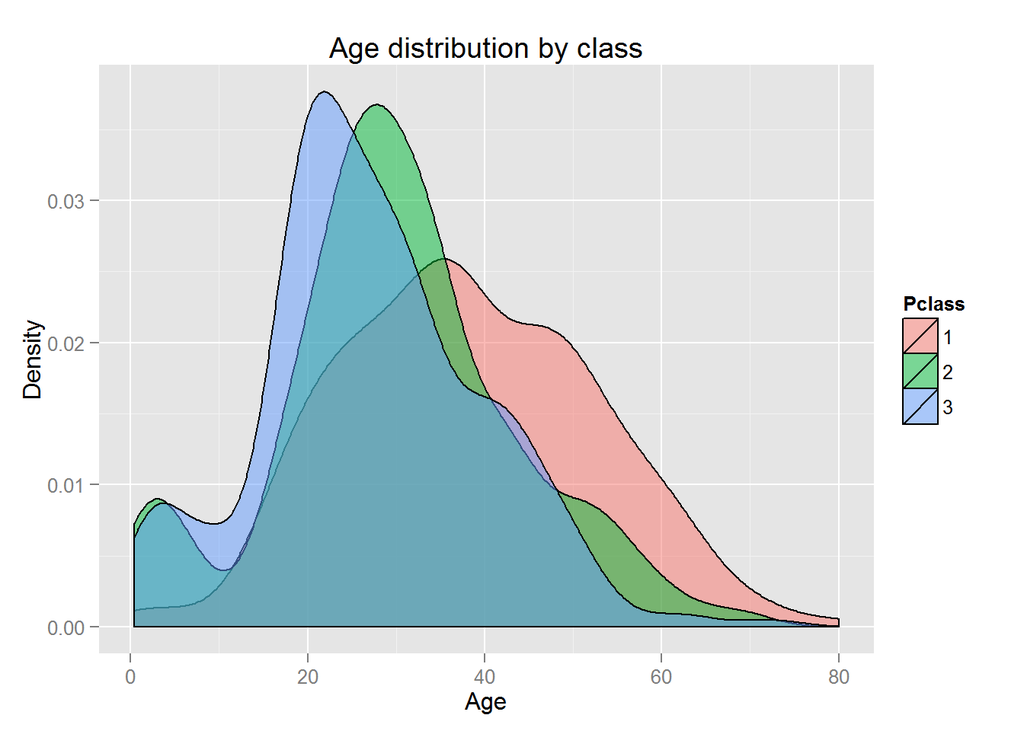

It looks like First class people were generally older than second class and so was the case with second class with third class.

The next step is to split the Train data into a Training Set & a Validation Set

```r
dataTrain<-train[1:700,]
dataVal<-train[701:nrow(train),]
```

What the above code means is that the first 700 rows of Train data are loaded into the data frame object “dataTrain” and the remaining rows are loaded into “dataVal”, which is going to be the validation set.

```r
#------------Model fitting Starts here-------------------------------#

library(rpart)
library(rattle)
```

[figure not shown]

```r
library(rpart.plot)
library(RColorBrewer)
library(neuralnet)
library(nnet)
library(e1071)
library(caret)
library(randomForest)
library(party)
library(caret)


#Applying Decision trees
fit <- rpart(Survived ~ Sex + Age + FamId + Pclass + Fare , data = dataTrain, method="class")
fancyRpartPlot(fit)
```

```r
dataVal$pred_dt <- predict(fit, dataVal[,-1], type = "class")
conf_Tree <- confusionMatrix(dataVal$pred_dt, dataVal$Survived)
#Confusion Matrix
tab=with(dataVal,table(True=Survived,Predicted=pred_dt))
print(tab)
```

```
##     Predicted
## True   0   1
##    0 110  10
##    1  19  52
```

```r
#Accuracy
sum(diag(tab)) / sum(tab)
```

```
## [1] 0.8481675
```

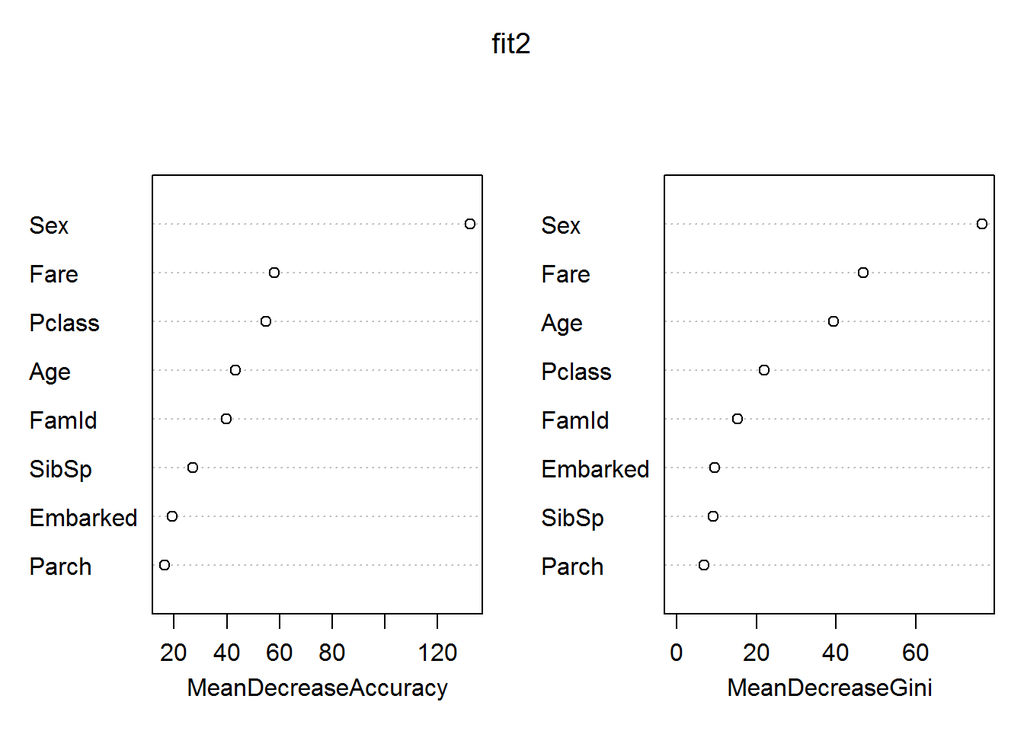

```r
# Random Forests
set.seed(415)
fit2<- randomForest(as.factor(Survived) ~ Pclass + Sex + Age + Fare + Embarked + FamId + Parch + SibSp, data=dataTrain,
                    importance=TRUE, ntree=2000)
varImpPlot(fit2)
```

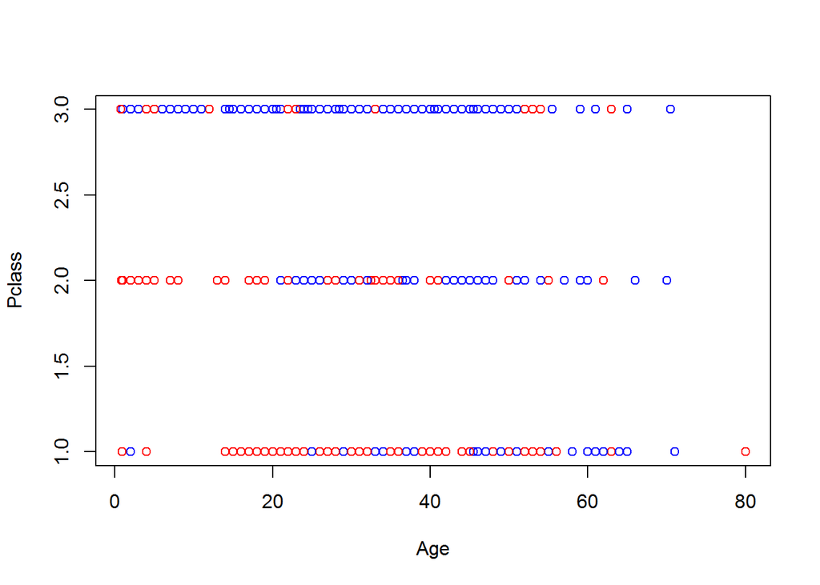

```r
dataVal$Pred_rf <- predict(fit2, dataVal)
Conf_RForest <- confusionMatrix(dataVal$Pred_rf, dataVal$Survived)



#C- forest
set.seed(415)
fit <- cforest(as.factor(Survived) ~ Pclass + Sex + Age + SibSp + Parch + Fare + Embarked + FamId, data = dataTrain, controls=cforest_unbiased(ntree=2000, mtry=3))

Pred_cf <- predict(fit, dataVal, OOB=TRUE, type = "response")
Conf_CForest <- confusionMatrix(Pred_cf, dataVal$Survived)




#SVM modelling
plot(dataTrain$Age, dataTrain$Pclass, xlab="Age", ylab="Pclass", col=ifelse(dataTrain$Survived==1, "red", "blue"))
```

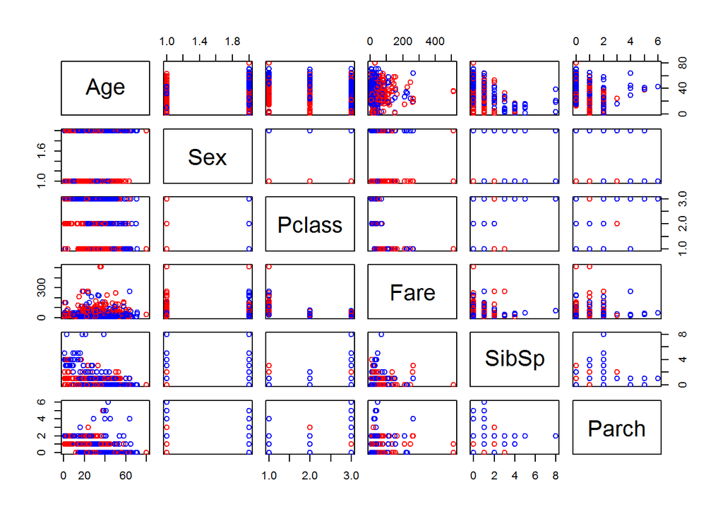

```r
pairs(~Age+Sex+Pclass+Fare+SibSp+Parch,data=dataTrain, col=ifelse(dataTrain$Survived==1, "red", "blue"))
```

```r
train_svm<-dataTrain[,c("Age","Sex","Pclass","SibSp","Parch","Survived")]
svm.model<-svm(Survived ~ . , data = train_svm, kernel="radial")

dataVal_svm<-dataVal[,c("Age","Sex","Pclass","SibSp","Parch")]
preds<-predict(svm.model, dataVal_svm)


conf_Svm  <- confusionMatrix(preds, dataVal$Survived)


#Applying Neural network

nnet1 = nnet(Survived ~ Sex + Pclass + Fare + Age + SibSp,
             data=dataTrain, size = 2, rang = 0.1,
             decay = 5e-4, maxit = 200)
prediction$net.result = predict(nnet1, dataVal)

for(i in 1:length(prediction$net.result)){
  if(prediction$net.result[i]>0.6){prediction$net.result[i]<-1}
  else{prediction$net.result[i]<-0}
}
conf_Neuralnet <- confusionMatrix(prediction$net.result, dataVal$Survived)


# Comparison of predictions from each model
compare_df <- data.frame(Accuracy = c(conf_Tree$overall[1],
                                      Conf_RForest$overall[1],
                                      Conf_CForest$overall[1],
                                      conf_Svm$overall[1],
                                      conf_Neuralnet$overall[1]),
                         row.names = c("rpart", "rf", "cforest", "svm", "neuralnet"))
compare_df
```

```
##            Accuracy
## rpart     0.8481675
## rf        0.8534031
## cforest   0.8481675
## svm       0.8481675
## neuralnet 0.8272251
```

Now it’s time for some “feature engineering”

```r
train$Child <- ifelse(train$Age<=18,1,0)
```

```r
train$Child <- as.factor(train$Child)
train$Survived <- as.factor(train$Survived)
table(train$Child, train$Survived)
```

```
##
##       0   1
##   0 473 269
##   1  76  73
```

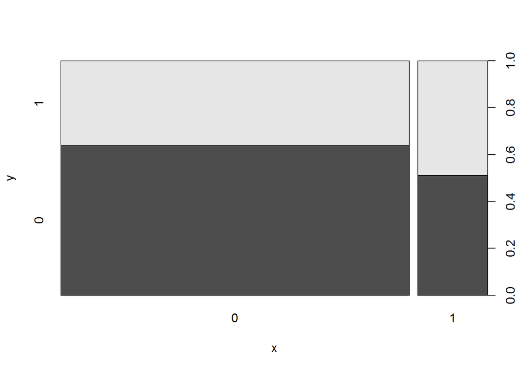

```r
plot(train$Child, train$Survived)
```

Looks like it doesn’t it - there is a ~50% chance that you survive if you are a child.

```r
train$Sex <- as.factor(train$Sex)
table(train$Child, train$Survived, by=train$Sex)
```

```
## , , by = female
##
##
##       0   1
##   0  58 187
##   1  23  46
##
## , , by = male
##
##
##       0   1
##   0 415  82
##   1  53  27
```

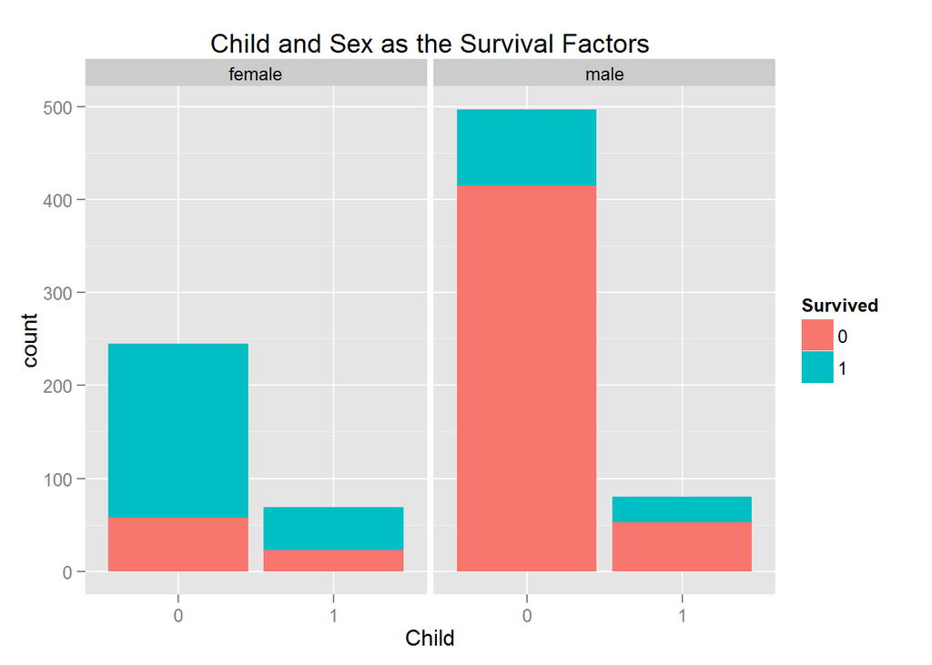

```r
ggplot(train, aes(Child)) +
  geom_bar(aes(fill = Survived )) +
  facet_grid(~Sex) +
  ggtitle("Child and Sex as the Survival Factors")
```

From here, it’s also somewhat evident that female children are more likely to survive.

Creating an indicator for Woman

```r
train$Woman <- ifelse(train$Sex=="female",1,0)
```

Creating another indicator for Child or Woman

```r
train$CoW <- ifelse(train$Child==1 | train$Woman==1,1,0)
```

NOW COMING TO THE VARIABLES RELATED TO FAMILY.

```r
train$FamilySize <- train$SibSp + train$Parch + 1
train$FamilyCat <- cut(train$FamilySize, c(0,1,4,12))
```

What is the family size of the individual? That’s what FamilySize gives you. In the next step, I have split the Family Sizes into 3 groups - those who are travelling alone, those whose family size is 2-4 and the third group of individuals whose family size is greater than 4.

To demonstrate how this works, let’s tabulate the FamilyCat and survival

```r
table(train$FamilyCat, train$Survived)
```

```
##
##            0   1
##   (0,1]  374 163
##   (1,4]  123 169
##   (4,12]  52  10
```

Individuals travelling alone and those with very high family sizes have a bad survival rate.

```r
train$PC3 <- ifelse(train$Pclass=="3",1,0)
```

I have decided to go with the following independent variables:

Pclass # Passenger class - the proxy for socio-economic status FamilyCat # Family Category - Family Size=1, Family Size 2-4, Family Size >4 Sex CoW # Is the passenger a Child or a woman? Title

I’m loading only these required variables into a new data frame:

```r
df_train <- train[,c("Survived","FamilyCat","Pclass","Sex","CoW","Title")]
```

The next step is to split the data into a Training Set & a Validation Set

```r
dataTrainfe<-df_train[1:700,]
dataValfe<-df_train[701:nrow(df_train),]
```

What the above code means is that the first 700 rows of data are loaded into the data frame object “dataTrainfe” and the remaining rows are loaded into “dataValfe”, which is going to be my validation set.

All my variables are categorical, so I’m converting them to factors.

```r
dataTrainfe$Survived <- as.factor(dataTrainfe$Survived)
dataTrainfe$Sex <- as.factor(dataTrainfe$Sex)
dataTrainfe$Title <- as.factor(dataTrainfe$Title)
dataTrainfe$Pclass <- as.factor(dataTrainfe$Pclass)
dataTrainfe$CoW <- as.factor(dataTrainfe$CoW)
dataTrainfe$FamilyCat <- as.factor(dataTrainfe$FamilyCat)
```

It’s time to move to the validation set. It is essential that we ensure that the datatypes of the input variables are the same across the training and validation sets.

```r
dataValfe$Survived <- as.factor(dataValfe$Survived)
dataValfe$Title <- as.factor(dataValfe$Title)
dataValfe$Sex <- as.factor(dataValfe$Sex)
dataValfe$CoW <- as.factor(dataValfe$CoW)
dataValfe$Pclass <- as.factor(dataValfe$Pclass)
dataValfe$FamilyCat <- as.factor(dataValfe$FamilyCat)

levels(dataValfe$Survived) <- levels(dataTrainfe$Survived)
levels(dataValfe$Title) <- levels(dataTrainfe$Title)
levels(dataValfe$Sex) <- levels(dataTrainfe$Sex)
levels(dataValfe$CoW) <- levels(dataTrainfe$CoW)
levels(dataValfe$Pclass) <- levels(dataTrainfe$Pclass)
levels(dataValfe$FamilyCat) <- levels(dataTrainfe$FamilyCat)
```

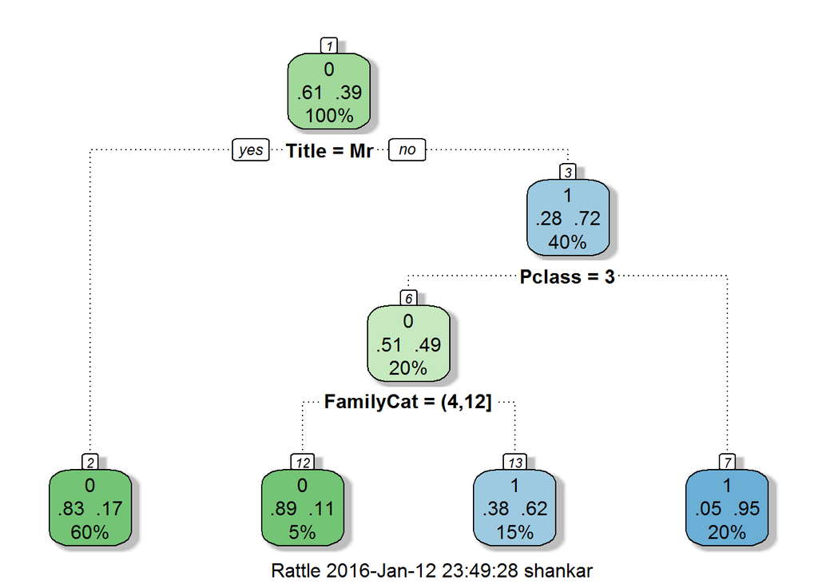

```r
#Applying Decision trees
fit_fe <- rpart(Survived~Pclass+Sex+CoW+FamilyCat+Title , data = dataTrainfe, method="class")
fancyRpartPlot(fit_fe)
```

```r
dataValfe$pred_dt <- predict(fit_fe, dataValfe[,-1], type = "class")
conf_Treefe <- confusionMatrix(dataValfe$pred_dt, dataValfe$Survived)
#Confusion Matrix
tab=with(dataValfe,table(True=Survived,Predicted=pred_dt))
print(tab)
```

```
##     Predicted
## True   0   1
##    0 109  11
##    1  16  55
```

```r
#Accuracy
sum(diag(tab)) / sum(tab)
```

```
## [1] 0.8586387
```

```r
#Applying Neural network

nnet1 = nnet(Survived~Pclass+Sex+CoW+FamilyCat+Title,
             data=dataTrainfe, size = 2, rang = 0.1,
             decay = 5e-4, maxit = 200)
```

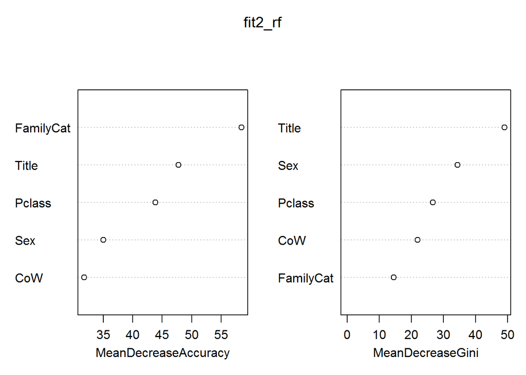

```r
prediction$net.result = predict(nnet1, dataValfe)

for(i in 1:length(prediction$net.result)){
  if(prediction$net.result[i]>0.6){prediction$net.result[i]<-1}
  else{prediction$net.result[i]<-0}
}
conf_Neuralnetfe <- confusionMatrix(prediction$net.result, dataValfe$Survived)

# Random Forests

set.seed(415)
fit2_rf<- randomForest(as.factor(Survived) ~ Pclass+Sex+CoW+FamilyCat+Title, data=dataTrainfe,
                    importance=TRUE, ntree=2000)
varImpPlot(fit2_rf)
```

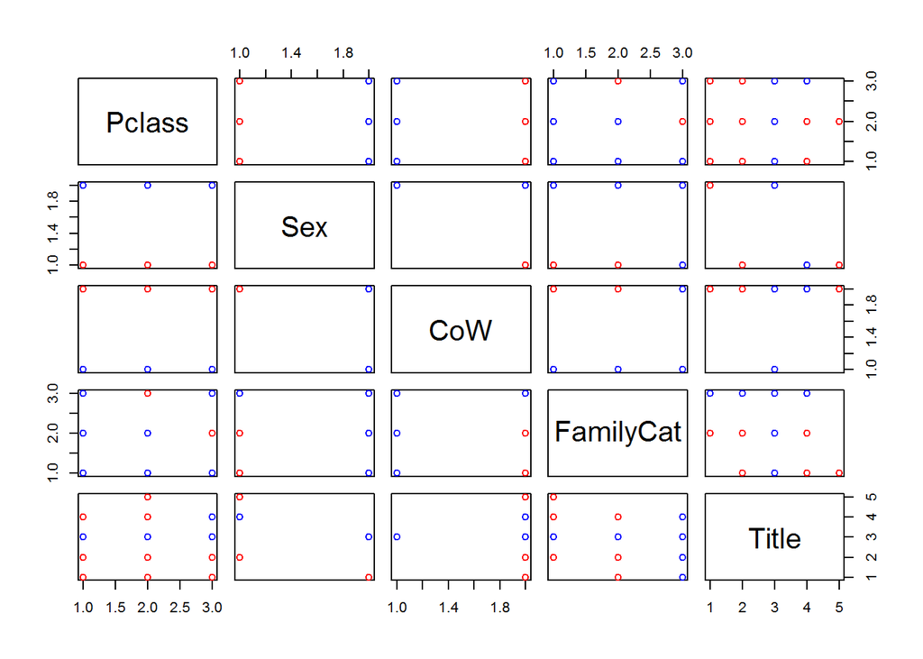

```r
prediction$Pred_rffe <- predict(fit2_rf,type="prob",dataValfe) [,2]
for(i in 1:length(prediction$Pred_rffe )){
  if(prediction$Pred_rffe[i]>0.6){prediction$Pred_rffe[i]<-1}
  else{prediction$Pred_rffe[i]<-0}
}
Conf_RForestfe <- confusionMatrix(prediction$Pred_rffe, dataValfe$Survived)



#C- forest
set.seed(415)
fit_cf <- cforest(Survived~Pclass+Sex+CoW+FamilyCat+Title, data = dataTrainfe, controls=cforest_unbiased(ntree=2000, mtry=3))

Predfe_cf <- predict(fit_cf, dataValfe, OOB=TRUE, type = "response")
Conf_CForestfe <- confusionMatrix(Predfe_cf, dataValfe$Survived)




#SVM modelling

pairs(~Pclass+Sex+CoW+FamilyCat+Title,data=dataTrainfe, col=ifelse(dataTrainfe$Survived==1, "red", "blue"))
```

```r
svm.model.fe<-svm(Survived~Pclass+Sex+CoW+FamilyCat+Title , data = dataTrainfe, kernel="radial")

preds<-predict(svm.model.fe, dataValfe)


conf_Svmfe  <- confusionMatrix(preds, dataValfe$Survived)


# Comparison of predictions from each model
compare_df <- data.frame(Accuracy = c(conf_Treefe$overall[1],
                                      Conf_RForestfe$overall[1],
                                      Conf_CForestfe$overall[1],
                                      conf_Svmfe$overall[1],
                                      conf_Neuralnetfe$overall[1]),
                         row.names = c("rpart", "rf", "cforest", "svm", "neuralnet"))
compare_df
```

```
##            Accuracy
## rpart     0.8586387
## rf        0.8638743
## cforest   0.8586387
## svm       0.8481675
## neuralnet 0.8376963
```

Preparing the TEST SET

The test set should possess the same variable definitions and data types as the train and validation set.

```r
summary(test$Age)
```

```
##    Min. 1st Qu.  Median    Mean 3rd Qu.    Max.
##    0.17   22.00   28.00   30.41   39.00   76.00
```

```r
test$Title <- as.factor(test$Title)
test$Child <- ifelse(test$Age<=18,1,0)
test$Woman <- ifelse(test$Sex=="female",1,0)
test$CoW <- ifelse(test$Child==1 | test$Woman==1,1,0) #Child or Woman
test$CoW <- as.factor(test$CoW)
test$FamilySize <- test$SibSp + test$Parch + 1
test$FamilyCat <- cut(test$FamilySize, c(0,1,4,12))
test$FamilyCat <- as.factor(test$FamilyCat)

levels(test$Age) <- levels(dataTrainfe$Age)
levels(test$Title) <- levels(dataTrainfe$Title)
levels(test$Sex) <- levels(dataTrainfe$Sex)
levels(test$CoW) <- levels(dataTrainfe$CoW)
levels(test$Pclass) <- levels(dataTrainfe$Pclass)
levels(test$FamilyCat) <- levels(dataTrainfe$FamilyCat)


test$Prob <- predict(fit2_rf,type="prob",newdata=test)[,2]
test$Survived <- ifelse(test$Prob >= 0.5, 1, 0)

write.csv(test[,c(1,20)],"final_file.csv", row.names=FALSE)
```